连续分布、函数分布、条件分布 | 0.8 | 2018-06-28

本周主要介绍连续分布的期望值定义和其公式，随机变量函数分布以及条件概率分布。

# 连续分布的期望值及性质

## 期望值近似推导

对于积分， $S = \sum_{-∞}^∞h(x)dx ≈ \sum_{n=-∞}^∞h(n\Delta)·\Delta$

对于连续随机变量 X，可以用近似的方法：

$X∈[0,\Delta) -> Y = 0\Delta$

$X∈[1\Delta,2\Delta) -> Y = 1\Delta$

$X∈[n\Delta,(n+1)\Delta) -> Y = n\Delta$

当 $\Delta -> 0, X ≈ Y$。

根据：$p_Y(n\Delta) = P(n\Delta \le X \lt n\Delta + \Delta) ≈ f_X(n\Delta)·\Delta$，那么有：

$$E[X] = \lim_{\Delta->0}E[Y] = \lim_{\Delta->0}\sum_{n->-∞}^∞n\Delta·P_Y(n\Delta) \\ = \lim_{\Delta->0}\sum_{n->-∞}^∞n\Delta·f_X(n\Delta)·\Delta = \int_{-∞}^∞xf_X(x)dx$$

## 期望值运算性质

同离散分布(不同的是Sum改成了积分):

连续分布的期望值函数为：$E[g(X)] = \int_{-∞}^∞g(x)·f_X(x)dx$

离散分布的期望值函数为：$E[g(X)] = \sum_{-∞}^∞g(x)·p_X(x)$

同理，可以得到 $E[a·g(X) + β·h(X)] = a·E[g(X)] + β·E[h(X)];\\E[a] = a\\E[X^n] = \int_{-∞}^∞x^nf_X(x)dx\\E[(X-\mu_X)^2] = \int_{-∞}^∞(x-\mu_x)^2f_X(x)dx$

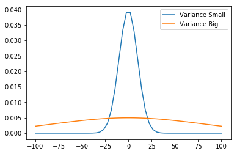

```python
from matplotlib import pyplot as plt;import numpy as np;
import scipy.stats as stats
xs = np.linspace(-100,100)
plt.plot(xs,stats.norm.pdf(xs,0,10),label="Variance Small")
plt.plot(xs,stats.norm.pdf(xs,0,80),label="Variance Big")
plt.legend()
```

# 常见连续分布的期望值/变异值

- $X -~ Exponential(\lambda)\\\mu_X = \frac{1}{\lambda}\\\sigma_X^2 = \frac{1}{\lambda^2}$
- $X -~ Erlang(n,\lambda)\\\mu_X = \frac{n}{\lambda}\\\sigma_X^2 = \frac{n}{\lambda^2}$
- $X -~ Gaussian(\mu,\sigma)\\\mu_X = \mu\\\sigma_X^2 = \sigma^2$

Exp: Exponsential 期望值推导：

根据：$\int Udv = UV - \int VdU\\\int_0^∞ \lambda e^{-\lambda x}dx = 1$

$$\mu_X = \int_{-∞}^∞xf_X(x)dx = \int_0^∞x·\lambda e^{-\lambda x}dx\\ = -\int_0^∞-x\lambda e^{-\lambda x}dx = -\int_0^∞x e^{-\lambda x}d(-\lambda x) = - \int_0^∞ xde^{-\lambda x} \\= \int_0^∞ e^{-\lambda x}dx = \frac{1}{\lambda}\int_0^∞ \lambda e^{-\lambda x}dx = \frac{1}{\lambda}$$

# 随机变量函数的分布

**Derived random variable**

## 离散变量分布

当 X 为随机变量，那么 Y = g(X) 也是随机变量：

$$p_{g(X)}(y) = \sum_{让g(x)=y的所有x}p_X(x)$$

例如：

[figure not shown]

## 连续变量分布

如果 X 为连续变量，那么 Y = g(X) 也是连续变量。区别是，不能直接算PDF，而最好先计算 g(X) 的 CDF：$F_{g(X)}(y) = P[g(X)\le y]，然后计算 CDF 的积分，然后求 PMF$

[figure not shown]

## 举例

[figure not shown]

# 条件概率的分布和失忆性

## 离散条件概率分布

[figure not shown]

如果 X 是离散随机变量，那么 PMF 为 $p_X(x)$。 如果已知某事件 B 已经发生，那么在这种条件下，概率分布为：

$$PMF:~p_{X|B}(x)=x∈B：\frac{p_X(x)}{P(B)},~x~ not ∈ B：0$$$$CDF:~F_{X|B}(x)=\sum_{\mu \le x} p_{X|B}(\mu) = \sum_{\mu \le x,\mu ∈ B}\frac{p_X(\mu)}{P(B)}$$

## 连续条件概率分布

[figure not shown]

如果 X 是连续随机变量，其 PDF 为 $f_X(x)$。如果某事件 B 已经发生，那么在这种情况下：

$$PDF:~f_{X|B}=x∈B：\frac{f_X(x)}{P(B)},~x ~ not ∈ B：0.$$$$CDF:~F_{X|B}(x)=\int_{-∞}^xf_{X|B}(\mu)d\mu = \int_{-∞\le \mu \le x,\mu ∈B}\frac{f_X(\mu)}{P(B)}d\mu$$

## 条件概率分布的期望值和方差

$$离散：E[X|B] = \sum_{x=-∞}^{∞}x·p_{X|B}(x)$$$$连续：E[X|B] = \int_{-∞}^{∞}x·f_{X|B}(x)dx$$$$离散：E[g(X)|B] = \sum_{x=-∞}^{∞}g(x)·p_{X|B}(x)$$$$连续：E[g(X)|B] = \int_{-∞}^{∞}g(x)·f_{X|B}(x)dx$$

$$Var(X|B) = E[(X|B - \mu_{X|B})^2] = E[(X - \mu_{X|B})^2|B] \\=E[X^2|B] - (\mu_{X|B})^2$$

## Exp 和 Geo 分布的失忆性

[figure not shown]